# tximport,DESeq2 Analysis Sucrose Date Palm Samples

Daniela Quijano NGS W10

```r
if (!require("BiocManager", quietly = TRUE))
    install.packages("BiocManager")
BiocManager::install("tximport")
a
```

```
  There is a binary version available but the source version is later:
```

|  | binary | source | needs_compilation |
| --- | --- | --- | --- |
| RColorBrewer | 1.1-2 | 1.1-3 | FALSE |

[output not shown]

```r
library('tximport')
library("DESeq2")
```

```r
#working Directory: /Users/danielaquijano/Documents/NYU Masters/SPRING 2022/NGS Class/Week 10/Week 10/
```

Import the “quant.sf” files for each sample into DESeq2 as a DESeqDataSet object.

```r
sample_names <- c('PDAC253','PDAC282','PDAC286','PDAC316','PDAC266','PDAC273','PDAC306','PDAC318')
sample_condition <- c(rep('highSucrose',4),rep('lowSucrose',4))
```

```r
files <- file.path('/Users/danielaquijano/Documents/NYU Masters/SPRING 2022/NGS Class/Week10',paste(sample_names,".transcripts_quant",sep=""),'quant.sf')

names(files) <- sample_names
```

```r
#Check that filepaths created in files actually exist by printing files and making sure file.exists()=T
 file.exists('/Users/danielaquijano/Documents/NYU Masters/SPRING 2022/NGS Class/Week10/PDAC253.transcripts_quant/quant.sf')
```

```
[1] TRUE
```

```r
print(files)
```

```
                                                                                                      PDAC253
"/Users/danielaquijano/Documents/NYU Masters/SPRING 2022/NGS Class/Week10/PDAC253.transcripts_quant/quant.sf"
                                                                                                      PDAC282
"/Users/danielaquijano/Documents/NYU Masters/SPRING 2022/NGS Class/Week10/PDAC282.transcripts_quant/quant.sf"
                                                                                                      PDAC286
"/Users/danielaquijano/Documents/NYU Masters/SPRING 2022/NGS Class/Week10/PDAC286.transcripts_quant/quant.sf"
                                                                                                      PDAC316
"/Users/danielaquijano/Documents/NYU Masters/SPRING 2022/NGS Class/Week10/PDAC316.transcripts_quant/quant.sf"
                                                                                                      PDAC266
"/Users/danielaquijano/Documents/NYU Masters/SPRING 2022/NGS Class/Week10/PDAC266.transcripts_quant/quant.sf"
                                                                                                      PDAC273
"/Users/danielaquijano/Documents/NYU Masters/SPRING 2022/NGS Class/Week10/PDAC273.transcripts_quant/quant.sf"
                                                                                                      PDAC306
"/Users/danielaquijano/Documents/NYU Masters/SPRING 2022/NGS Class/Week10/PDAC306.transcripts_quant/quant.sf"
                                                                                                      PDAC318
"/Users/danielaquijano/Documents/NYU Masters/SPRING 2022/NGS Class/Week10/PDAC318.transcripts_quant/quant.sf"
```

```r
tx2gene <- read.table('/Users/danielaquijano/Documents/NYU Masters/SPRING 2022/NGS Class/Week10/Pdac_Barhee_chr_unan_180126_maker_HC.tx2gene',header=F,sep=",")
```

```r
txi <- tximport(files, type="salmon", tx2gene=tx2gene)
```

```
reading in files with read_tsv
1 2 3 4 5 6 7 8
summarizing abundance
summarizing counts
summarizing length
```

```r
samples <- data.frame(sample_names=sample_names,condition=sample_condition)
row.names(samples) <- sample_names
```

```r
samples
```

|  | sample_names | condition |
| --- | --- | --- |
| PDAC253 | PDAC253 | highSucrose |
| PDAC282 | PDAC282 | highSucrose |
| PDAC286 | PDAC286 | highSucrose |
| PDAC316 | PDAC316 | highSucrose |
| PDAC266 | PDAC266 | lowSucrose |
| PDAC273 | PDAC273 | lowSucrose |
| PDAC306 | PDAC306 | lowSucrose |
| PDAC318 | PDAC318 | lowSucrose |

```r
# create DESeqDataSet object

ddsTxi <- DESeqDataSetFromTximport(txi,
                                   colData = samples,
                                   design = ~ condition)
class(ddsTxi)
```

```
[1] "DESeqDataSet"
attr(,"package")
[1] "DESeq2"
```

```r
#8 columns (samples), 28340 rows (genes)
ddsTxi
```

```
class: DESeqDataSet
dim: 28340 8
metadata(1): version
assays(2): counts avgTxLength
rownames(28340): Pdac_HC_000007FG0000100 Pdac_HC_000007FG0000200 ...
  Pdac_HC_chr9G0155000 Pdac_HC_chr9G0155100
rowData names(0):
colnames(8): PDAC253 PDAC282 ... PDAC306 PDAC318
colData names(2): sample_names condition
```

For deseq analysis, remove genes with fewer than 10 reads and use “lfcShrink” in favor of the “results” function when creating the DESeqResults object. Take care in defining the “contrast” argument to lfcShrink (see Week 9 Assignment). The output should be a set of results ordered based on the adjusted p-value.

```r
library(dplyr)
```

```r
library(pheatmap)
```

```r
library(ggplot2)
```

```r
#removing genes with 10 or fewer reads
keep <- rowSums(counts(ddsTxi)) >= 10
ddsTxi <- ddsTxi[keep,]
```

```r
#run the DESeq wrapper function.

ddsTxi <- DESeq(ddsTxi)
```

```
using 'avgTxLength' from assays(dds), correcting for library size
```

```r
class(ddsTxi) # Determine the type of object
```

```
[1] "DESeqDataSet"
attr(,"package")
[1] "DESeq2"
```

```r
rawcounts.matrix <- counts(ddsTxi,normalized=F)
normalizedcounts.matrix <- counts(ddsTxi,normalized=T)
class(rawcounts.matrix)
```

```
[1] "matrix" "array"
```

```r
head(normalizedcounts.matrix)
```

```
                           PDAC253    PDAC282     PDAC286    PDAC316
Pdac_HC_000007FG0000100 109.704208 123.596721   53.749177 144.051138
Pdac_HC_000007FG0000200  20.008589  31.264120   28.608906  25.175951
Pdac_HC_000007FG0000300 426.289552 386.004495  486.252243 520.406191
Pdac_HC_000007FG0000400 182.945107 315.410003 1865.817719 315.351823
Pdac_HC_000007FG0000500   4.181159   6.428079    1.339707   3.149265
Pdac_HC_000007FG0000600  17.225656  85.647834  106.381876  64.987084
                          PDAC266    PDAC273     PDAC306    PDAC318
Pdac_HC_000007FG0000100 223.97947 125.135921  110.249240 203.791592
Pdac_HC_000007FG0000200  33.68535  44.440913   29.019411  40.622901
Pdac_HC_000007FG0000300 373.84199 284.194412  330.003187 383.484338
Pdac_HC_000007FG0000400 432.07579 357.535442 1106.680682 502.517118
Pdac_HC_000007FG0000500  35.60079   8.881635    6.635475   7.117842
Pdac_HC_000007FG0000600 290.84857  90.266906   91.819716 131.942203
```

```r
ddsTxi
```

```
class: DESeqDataSet
dim: 20869 8
metadata(1): version
assays(6): counts avgTxLength ... H cooks
rownames(20869): Pdac_HC_000007FG0000100 Pdac_HC_000007FG0000200 ...
  Pdac_HC_chr9G0155000 Pdac_HC_chr9G0155100
rowData names(22): baseMean baseVar ... deviance maxCooks
colnames(8): PDAC253 PDAC282 ... PDAC306 PDAC318
colData names(2): sample_names condition
```

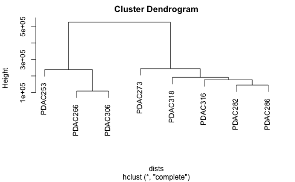

```r
# “rlog” transform the normalized counts and perform hierarchical clustering of samples:
rld <- rlog(ddsTxi)
dists <- dist(t(assay(ddsTxi)))
plot(hclust(dists))
```

```r
#Distance Matrix
dists
```

```
         PDAC253  PDAC282  PDAC286  PDAC316  PDAC266  PDAC273  PDAC306
PDAC282 453665.5
PDAC286 423968.3 144663.5
PDAC316 407319.9 177224.4 158907.8
PDAC266 237909.5 370922.7 326015.2 329257.9
PDAC273 525035.6 185391.0 206458.5 226407.7 410182.9
PDAC306 156933.8 388647.9 342745.9 338336.1 108337.7 447732.1
PDAC318 321308.6 191475.8 153728.4 181777.5 208544.2 244546.7 231513.7
```

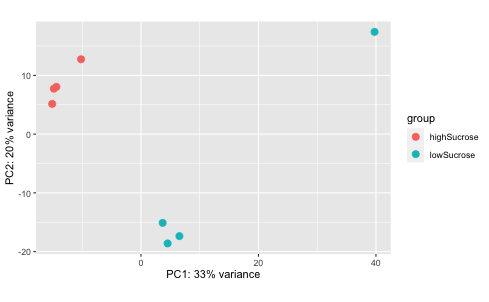

```r
#Make PCA plot
plotPCA(rld)
```

Contrast defined relative to low sucrose.

```r
#Results from the DESeq2 analysis can be extracted from the DESeqDataSet object using the results function.
res <- results(ddsTxi, contrast = c('condition','lowSucrose','highSucrose') )
class(res)
```

```
[1] "DESeqResults"
attr(,"package")
[1] "DESeq2"
```

### Q3.3. Report the results table for the top 10 differentially expressed genes according to adjusted p-value (i.e., FDR).

```r
#sort the data ascending on p-value.
#most significant differentially expressed gene at the top.
resOrdered <- res[order(res$pvalue),]
head(resOrdered,10) # View the 10 most significant genes
```

```
log2 fold change (MLE): condition lowSucrose vs highSucrose
Wald test p-value: condition lowSucrose vs highSucrose
DataFrame with 10 rows and 6 columns
                         baseMean log2FoldChange     lfcSE      stat
                        <numeric>      <numeric> <numeric> <numeric>
Pdac_HC_chr14G0022900   8501.9994        9.77284  0.611325  15.98633
Pdac_HC_chr14G0099800    634.3442      -11.12936  0.893957 -12.44955
Pdac_HC_000288FG0001200  286.4387        4.47849  0.443570  10.09647
Pdac_HC_chr14G0023100   6924.3989        6.14033  0.642618   9.55518
Pdac_HC_chr15G0001700    120.6265       10.14597  1.072122   9.46344
Pdac_HC_002675FG0000200   56.4347       -5.04492  0.578963  -8.71372
Pdac_HC_chr3G0041200      45.1900       -9.14916  1.072433  -8.53122
Pdac_HC_000654FG0000200   79.5471       -8.57155  1.017587  -8.42341
Pdac_HC_chr14G0000300     73.0425       -3.98599  0.496102  -8.03462
Pdac_HC_chr14G0000200    115.4159       -3.86422  0.481188  -8.03058
                             pvalue        padj
                          <numeric>   <numeric>
Pdac_HC_chr14G0022900   1.59132e-57 2.76922e-53
Pdac_HC_chr14G0099800   1.40643e-35 1.22374e-31
Pdac_HC_000288FG0001200 5.72648e-24 3.32174e-20
Pdac_HC_chr14G0023100   1.23364e-21 5.36694e-18
Pdac_HC_chr15G0001700   2.97971e-21 1.03706e-17
Pdac_HC_002675FG0000200 2.94068e-18 8.52896e-15
Pdac_HC_chr3G0041200    1.44816e-17 3.60013e-14
Pdac_HC_000654FG0000200 3.65695e-17 7.95477e-14
Pdac_HC_chr14G0000300   9.38692e-16 1.68823e-12
Pdac_HC_chr14G0000200   9.70137e-16 1.68823e-12
```

#Q3.2 Histogram trend:

an enrichment of low p-values. This is the expected result if there is a large class of differentially expressed genes between treatment and control.

```
Warning: Removed 250 rows containing non-finite values (stat_bin).
```

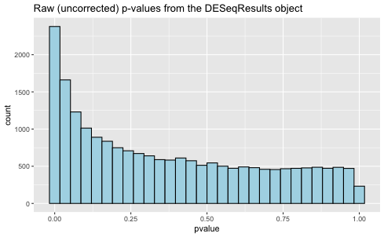

```r
ggplot(as.data.frame(res),aes(pvalue)) + geom_histogram(fill="light blue",color='black')+ggtitle('Raw (uncorrected) p-values from the DESeqResults object')
```

```r
#Filter genes from normalized counts using the top 30 most expressed genes
norm_counts_top_30=normalizedcounts.matrix[rownames(head(resOrdered,30)), ]
```

```r
head(norm_counts_top_30)
```

```
                           PDAC253    PDAC282    PDAC286     PDAC316
Pdac_HC_chr14G0022900     18.89092   12.91353   42.64883    4.746155
Pdac_HC_chr14G0099800   1205.47336 1006.27188 1184.58370 1677.160847
Pdac_HC_000288FG0001200   26.91631   17.91693   12.32149   40.948228
Pdac_HC_chr14G0023100     30.73050  184.81879  439.09359  118.930971
Pdac_HC_chr15G0001700      0.00000    0.00000    0.00000    0.000000
Pdac_HC_002675FG0000200   89.06550  172.57181   85.07067   91.010059
                           PDAC266      PDAC273     PDAC306      PDAC318
Pdac_HC_chr14G0022900   28390.7497 21134.155337 8072.838101 10339.052336
Pdac_HC_chr14G0099800       0.0000     1.263895    0.000000     0.000000
Pdac_HC_000288FG0001200   697.1431   729.910716  454.607640   311.745070
Pdac_HC_chr14G0023100   22081.4194 15055.998671 7036.699787 10447.499346
Pdac_HC_chr15G0001700     205.7576   211.476792  329.840901   217.936658
Pdac_HC_002675FG0000200     0.0000     3.636150    5.670601     4.452806
```

```r
sampleTable <- data.frame(sampleName = sample_names,
                          fileName = sample_names,
                          condition = sample_condition)
```

```r
#Here I arrange the annotation columns to generate an annotated and clsutered heatmap using pheatmap
annotation_columns=sampleTable
annotation_columns
```

| sampleName | fileName | condition |
| --- | --- | --- |
| PDAC253 | PDAC253 | highSucrose |
| PDAC282 | PDAC282 | highSucrose |
| PDAC286 | PDAC286 | highSucrose |
| PDAC316 | PDAC316 | highSucrose |
| PDAC266 | PDAC266 | lowSucrose |
| PDAC273 | PDAC273 | lowSucrose |
| PDAC306 | PDAC306 | lowSucrose |
| PDAC318 | PDAC318 | lowSucrose |

```r
annotation_columns$fileName <- NULL
annotation_columns
```

| sampleName | condition |
| --- | --- |
| PDAC253 | highSucrose |
| PDAC282 | highSucrose |
| PDAC286 | highSucrose |
| PDAC316 | highSucrose |
| PDAC266 | lowSucrose |
| PDAC273 | lowSucrose |
| PDAC306 | lowSucrose |
| PDAC318 | lowSucrose |

```r
row.names(annotation_columns) <- colnames(norm_counts_top_30)
```

```r
annotation_columns
```

|  | sampleName | condition |
| --- | --- | --- |
| PDAC253 | PDAC253 | highSucrose |
| PDAC282 | PDAC282 | highSucrose |
| PDAC286 | PDAC286 | highSucrose |
| PDAC316 | PDAC316 | highSucrose |
| PDAC266 | PDAC266 | lowSucrose |
| PDAC273 | PDAC273 | lowSucrose |
| PDAC306 | PDAC306 | lowSucrose |
| PDAC318 | PDAC318 | lowSucrose |

```r
annotation_columns$sampleName <- NULL
```

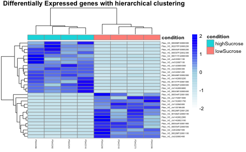

```r
pheatmap(norm_counts_top_30, color=colorRampPalette(c("white", "light blue", "blue"))(30), scale="row", cluster_cols = T, show_rownames = T,fontsize_row = 4, fontsize_col = 4,labels_row = rownames(dists),main='Differentially Expressed genes with hierarchical clustering',annotation_col =annotation_columns )
```

### Q3.3

Candidate genes:

Pdac_HC_chr14G0022900 (cell wall invertase enzyme)

Pdac_HC_chr14G0023100 (cell wall invertase enzyme)

Pdac_HC_chr14G0028200 (alkaline/neutral invertase enzyme)

The gene that is likely biologically and statistifcallhy differentially expressed is Pdac_HC_chr14G0022900. The p value is really small at 1.59e-57 and the log fold change is almost ten. The gene Pdac_HC_chr14G0023100 is also likely biologically and statistically differentially expressed with a 6 fold log fold change and p value at 1.23e-21 p value. It is hard to say whether the last gene, Pdac_HC_chr14G0028200 is differentially expressed since the log fold change is not very high at 0.48 and the p value is 4.8e-2 which would not pass an FDR correction.

```r
gene_search=c('Pdac_HC_chr14G0022900','Pdac_HC_chr14G0023100','Pdac_HC_chr14G0028200')
#Filter results dataframe with a list.
gene_search_results<-resOrdered[c(gene_search),]
gene_search_results
```

```
log2 fold change (MLE): condition lowSucrose vs highSucrose
Wald test p-value: condition lowSucrose vs highSucrose
DataFrame with 3 rows and 6 columns
                       baseMean log2FoldChange     lfcSE      stat      pvalue        padj
                      <numeric>      <numeric> <numeric> <numeric>   <numeric>   <numeric>
Pdac_HC_chr14G0022900  8501.999       9.772844  0.611325  15.98633 1.59132e-57 2.76922e-53
Pdac_HC_chr14G0023100  6924.399       6.140332  0.642618   9.55518 1.23364e-21 5.36694e-18
Pdac_HC_chr14G0028200   582.729       0.487421  0.247031   1.97311 4.84827e-02 2.26071e-01
```

### Q3.4

In this plot, black values are the original genewise dispersion values and blue are the adjusted values based on the model fit (red line) Generate three dispersion-mean plots for all three methods (‘parametric’,‘local’ and ‘mean’)

As seen in the plots below the main difference is in the shape of the fitted line. Both parametric and local look very similar. The fit line for mean is completely horizontal and it brings the rest of the points closer to the mean.

I do not think that the trend line fit type should be changed from parametric to another setting because the dispersion estimates slightly decrease over the mean but then converge. In this case parametric is a suitable fit type.

```r
par_disp <- estimateDispersions(ddsTxi, fitType = "parametric")
```

```
found already estimated dispersions, replacing these
```

```r
loc_dip <- estimateDispersions(ddsTxi, fitType = "local")
```

```
found already estimated dispersions, replacing these
```

```r
avg_disp<-estimateDispersions(ddsTxi, fitType = "mean")
```

```
found already estimated dispersions, replacing these
```

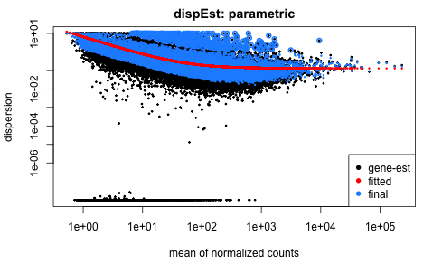

```r
plotDispEsts(par_disp, main= "dispEst: parametric")
```

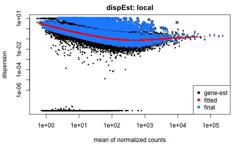

```r
plotDispEsts(loc_dip, main= "dispEst: local")
```

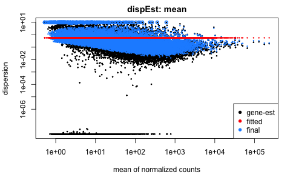

```r
plotDispEsts(avg_disp, main= "dispEst: mean")
```

### Q3.5 What are three reasons why the Salmon + tximport + DESeq2 workflow may be preferred over the STAR + htseq-count + DESeq2 workflow? [ 1 point ]

-length variation among alternative splice variants is not accounted for in the STAR + htseq-count + DESeq2 and related workflows. According to documentation, salmon and tximport workflow’ corrects for any potential changes in gene length across samples’ -According to documentation you can save time and disk space using salmon and tximport -You can avoid discarding reads that map to multiple genes.